# Trees of Cologne - Bäume in Köln

Moritz Seidel

## Why?

Having discovered that the City of Cologne has published a dataset with a lot of informations on the trees in the city (not all of them but many - to be precise: exactly 134.189 trees) I wanted to know wether I can make visible some interessting things with this data:

1. Where in the city can I find especially old trees?
2. Can I make visible some of the city’s climate adaption politics with this data? Actually the city of Cologne started experimenting with non-domestic trees ten years ago. The aim is to find trees that show for example a higher resistance to heat waves which occure more often due to climate change or are more comfortable with the increasing average temperature.

Additionally the city plans to complete this dataset until all of the trees are in there. So maybe over time this analysis can get more precise.

## The data

The dataset can be found here: https://offenedaten-koeln.de/sites/default/files/Bestand_Einzelbaeume_Koeln_0.csv. I will combine it with some shape files to create maps later on.

## A first look at the tree’s ages

After having cleaned up the data a little, I created a new variable “Heimisch”, which tells me for each species if it is domestic or not.

```r
datatrees_domestic <- datatrees_narrow %>%
  mutate(Heimisch=case_when(
    DeutscherN=="Ahorn" ~ "Heimisch",
    DeutscherN=="Amberbaum" ~ "Andere",
    DeutscherN=="Amerikanische Linde" ~ "Andere",
    DeutscherN=="Amerikanische Rot-Eiche" ~ "Andere",
    DeutscherN=="Amerikanische Stadt-Linde" ~ "Andere",
    DeutscherN=="Amerikanischer Tulpenbaum" ~ "Andere",
    DeutscherN=="Apfel" ~ "Heimisch",
    DeutscherN=="Atlas-Zeder" ~ "Andere",
    DeutscherN=="Baumhasel" ~ "Andere",
    DeutscherN=="Berg-Ulme" ~ "Heimisch",
    DeutscherN=="Bergahorn" ~ "Heimisch",
    DeutscherN=="Birke" ~ "Heimisch",
    DeutscherN=="Birne" ~ "Heimisch",
    DeutscherN=="Blasenbaum" ~ "Andere",
    DeutscherN=="Blauglockenbaum" ~ "Andere",
    DeutscherN=="Blumen-Esch" ~ "Andere",
    DeutscherN=="Blut-Ahorn, Spitzahorn" ~ "Heimisch",
    DeutscherN=="Blut-Pflaume" ~ "Heimisch",
    DeutscherN=="Chinesische Ulme" ~ "Andere",
    DeutscherN=="Coloradotanne" ~ "Andere",
    DeutscherN=="Crataegus, Dorn" ~ "Heimisch",
    DeutscherN=="Dreidorniger Lederhülsenbaum, Gleditschie" ~ "Andere",
    DeutscherN=="Eberesche, Mehlbeere, Vogelbeerbaum" ~ "Heimisch",
    DeutscherN=="Echter Korkbaum, Amur-Korkbaum" ~ "Andere",
    DeutscherN=="Echter Rotdorn" ~ "Heimisch",
    DeutscherN=="Eibe" ~ "Heimisch",
    DeutscherN=="Eiche" ~ "Heimisch",
    DeutscherN=="Einblättrige Esche" ~ "Andere",
    DeutscherN=="Eisenbaum" ~ "Andere",
    DeutscherN=="Eisenholzbaum" ~ "Andere",
    DeutscherN=="Erle" ~ "Heimisch",
    DeutscherN=="Esche" ~ "Heimisch",
    DeutscherN=="Eschen-Ahorn" ~ "Andere",
    DeutscherN=="Etagen Hartriegel" ~ "Andere",
    DeutscherN=="Fächer-Ahorn" ~ "Andere",
    DeutscherN=="Farn- oder geschlitzblättrige Birke" ~ "Andere",
    DeutscherN=="Feldahorn" ~ "Heimisch",
    DeutscherN=="Felsenbirne" ~ "Heimisch",
    DeutscherN=="Feuerahorn" ~ "Andere",
    DeutscherN=="Fichte" ~ "Heimisch",
    DeutscherN=="Flügelnuß" ~ "Heimisch",
    DeutscherN=="Gelbe Gleditschie" ~ "Andere",
    DeutscherN=="Gemeine Esche" ~ "Heimisch",
    DeutscherN=="Gemeiner Goldregen" ~ "Andere",
    DeutscherN=="Gemeiner Judasbaum, Herzbaum" ~ "Andere",
    DeutscherN=="Gewöhnliche Eberesche" ~ "Heimisch",
    DeutscherN=="Gewöhnliche Kiefer" ~ "Heimisch",
    DeutscherN=="Ginkgo" ~ "Andere",
    DeutscherN=="Ginkgobaum, Fächerblattbaum" ~ "Andere",
    DeutscherN=="Gleditsie, Lederhülsenbaum" ~ "Andere",
    DeutscherN=="Goldrobinie" ~ "Andere",
    DeutscherN=="Götterbaum" ~ "Andere",
    DeutscherN=="Großblättrige Sommerlinde" ~ "Heimisch",
    DeutscherN=="Grüne Hängebuche" ~ "Heimisch",
    DeutscherN=="Hainbuche, Weißbuche" ~ "Heimisch",
    DeutscherN=="Hasel" ~ "Heimisch",
    DeutscherN=="Holzbirne, Gemeine Birne" ~ "Heimisch",
    DeutscherN=="Hopfenbuche" ~ "Andere",
    DeutscherN=="Italienische Erle" ~ "Andere",
    DeutscherN=="Japanische Nelken-Kirsche" ~ "Andere",
    DeutscherN=="Japanischer Schnurbaum" ~ "Andere",
    DeutscherN=="Judasblattbaum, Lebkuchenbaum" ~ "Andere",
    DeutscherN=="Kaiserlinde" ~ "Heimisch",
    DeutscherN=="Kanadische Hemlocktanne" ~ "Andere",
    DeutscherN=="Kanadische Holz-Pappel" ~ "Andere",
    DeutscherN=="Kastanie" ~ "Heimisch",
    DeutscherN=="Kegel-Robinie" ~ "Andere",
    DeutscherN=="Kiefer" ~ "Heimisch",
    DeutscherN=="Kirsche" ~ "Heimisch",
    DeutscherN=="Kolchischer Ahorn" ~ "Andere",
    DeutscherN=="Krimlinde" ~ "Heimisch",
    DeutscherN=="Kugel-Trompetenbaum" ~ "Andere",
    DeutscherN=="Kugelahorn" ~ "Heimisch",
    DeutscherN=="Kugelrobinie" ~ "Andere",
    DeutscherN=="Kupfer-Felsenbirne" ~ "Andere",
    DeutscherN=="Küstenmammutbaum" ~ "Andere",
    DeutscherN=="Lebensbaum" ~ "Andere",
    DeutscherN=="Lederblättriger Weißdorn" ~ "Andere",
    DeutscherN=="Libanon-Zeder" ~ "Andere",
    DeutscherN=="Linde" ~ "Heimisch",
    DeutscherN=="Lorbeermispel, Glanzmispel" ~ "Andere",
    DeutscherN=="Magnolie" ~ "Andere",
    DeutscherN=="Mammutbaum" ~ "Andere",
    DeutscherN=="Marone, Eßkastanie" ~ "Andere",
    DeutscherN=="Mehlbeere" ~ "Heimisch",
    DeutscherN=="Österreichische Schwarzkiefer" ~ "Andere",
    DeutscherN=="Papierbirke" ~ "Andere",
    DeutscherN=="Pappel" ~ "Heimisch",
    DeutscherN=="Pfaffenhütchen (Spindelbaum" ~ "Heimisch",
    DeutscherN=="Platane" ~ "Heimisch",
    DeutscherN=="Purpur-Kastanie, Blut-Kastanie" ~ "Heimisch",
    DeutscherN=="Pyramiden-Eiche, Säulen-Eiche" ~ "Heimisch",
    DeutscherN=="Pyramiden-Hainbuche" ~ "Heimisch",
    DeutscherN=="Roßkastanie" ~ "Heimisch",
    DeutscherN=="Rot-Buche" ~ "Heimisch",
    DeutscherN=="Rotahorn" ~ "Andere",
    DeutscherN=="Roter Holunder" ~ "Heimisch",
    DeutscherN=="Rundblättrige Rotbuche" ~ "Heimisch",
    DeutscherN=="Sal-Weide" ~ "Heimisch",
    DeutscherN=="Sandbirke" ~ "Heimisch",
    DeutscherN=="Sanddorn" ~ "Heimisch",
    DeutscherN=="Säulen-Tulpenbaum" ~ "Andere",
    DeutscherN=="Säulen-Ulme" ~ "Heimisch",
    DeutscherN=="Säulenpappel, Pyramidenpappel" ~ "Heimisch",
    DeutscherN=="Säulenrobinie" ~ "Andere",
    DeutscherN=="Scheinakazie" ~ "Andere",
    DeutscherN=="Scheinzypresse" ~ "Andere",
    DeutscherN=="Schmalkroniger Rotahorn" ~ "Andere",
    DeutscherN=="Schnurbaum" ~ "Andere",
    DeutscherN=="Schwarz-Erle, Rot-Erle" ~ "Heimisch",
    DeutscherN=="Schwarzer Holunder" ~ "Heimisch",
    DeutscherN=="Schwarzkiefer" ~ "Andere",
    DeutscherN=="Schwarznuß" ~ "Andere",
    DeutscherN=="Schwarzpappel" ~ "Heimisch",
    DeutscherN=="Schwedische Mehlbeere" ~ "Andere",
    DeutscherN=="Silber-Ahorn" ~ "Andere",
    DeutscherN=="Silber-Weide" ~ "Heimisch",
    DeutscherN=="Silberlinde" ~ "Andere",
    DeutscherN=="Silberpappel" ~ "Heimisch",
    DeutscherN=="Sommer-Eiche, Stieleiche" ~ "Heimisch",
    DeutscherN=="Späte Traubenkirsche" ~ "Andere",
    DeutscherN=="Späth's Erle" ~ "Heimisch",
    DeutscherN=="Spitzahorn" ~ "Heimisch",
    DeutscherN=="Spitzahorn Cleveland" ~ "Andere",
    DeutscherN=="Stechpalme" ~ "Heimisch",
    DeutscherN=="Straßen-Akazie" ~ "Andere",
    DeutscherN=="Sumpf-Eiche" ~ "Andere",
    DeutscherN=="Tanne" ~ "Heimisch",
    DeutscherN=="Trauben-Kirsche" ~ "Heimisch",
    DeutscherN=="Trompetenbaum" ~ "Andere",
    DeutscherN=="Tulpenbaum" ~ "Andere",
    DeutscherN=="Ulme, Rüster" ~ "Heimisch",
    DeutscherN=="Ungarische Eiche" ~ "Andere",
    DeutscherN=="Ungarische Silberlinde" ~ "Andere",
    DeutscherN=="Urweltmammutbaum, Chinesisches Rotholz" ~ "Andere",
    DeutscherN=="Wacholder" ~ "Heimisch",
    DeutscherN=="Wal-, Nußbaum" ~ "Heimisch",
    DeutscherN=="Walnuß" ~ "Heimisch",
    DeutscherN=="Weide" ~ "Heimisch",
    DeutscherN=="Weißdorn" ~ "Heimisch",
    DeutscherN=="Winter-Eiche, Trauben-Eiche" ~ "Heimisch",
    DeutscherN=="Winterlinde" ~ "Heimisch",
    DeutscherN=="Winterlinde Cordaley" ~ "Heimisch",
    DeutscherN=="Winterlinde Dila" ~ "Heimisch",
    DeutscherN=="Zeder" ~ "Andere",
    DeutscherN=="Zelkove" ~ "Andere",
    DeutscherN=="Zier-Birne" ~ "Heimisch",
    DeutscherN=="Zierapfel" ~ "Heimisch",
    DeutscherN=="Zierkirsche 'Spire'" ~ "Heimisch"
  )) %>%
  filter(!is.na(Heimisch))
```

Then I did the same thing again with the spatial data.

I also had to join the shape files of the trees dataset with shape files making me able to display the City of Cologne and its quarters.

```r
trees_joined <- trees_domestic %>%
  st_transform(crs=st_crs(cologne))
cologne_trees <- st_join(cologne, trees_joined, left=T)
```

## A first insight

Having done all the preparations I wanted to have an overview of the age distribution of domestic and non domestic trees. The following barchart helps:

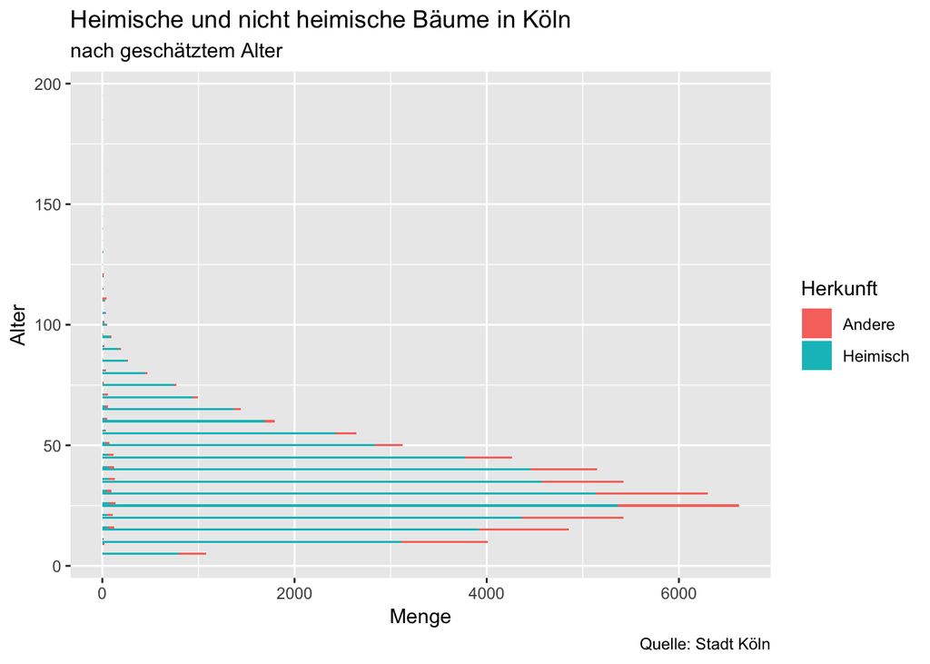

So domestic trees are clearly dominating the age groups - also for the past 10 years. But maybe I can discover something interessting by having a look at geographical distribution.

## Mapping

At first I simply looked at the average age of the trees per city quarter:

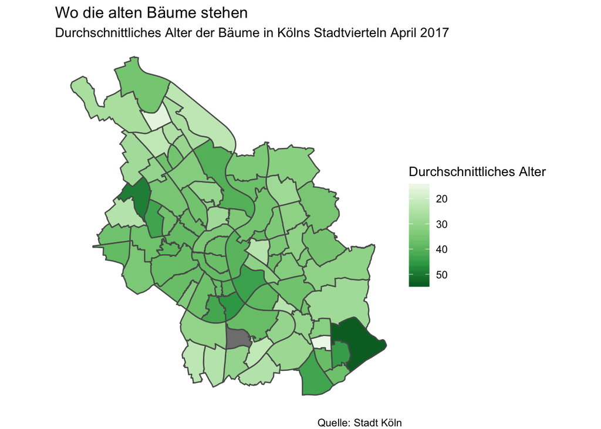

Not that revealing. So I tried with a map showing the average age of the trees per city quarter but faceted by species:

[figure not shown]

Interesting but not a good overview. So I used my variable “Heimisch” again to facet only by domestic or not:

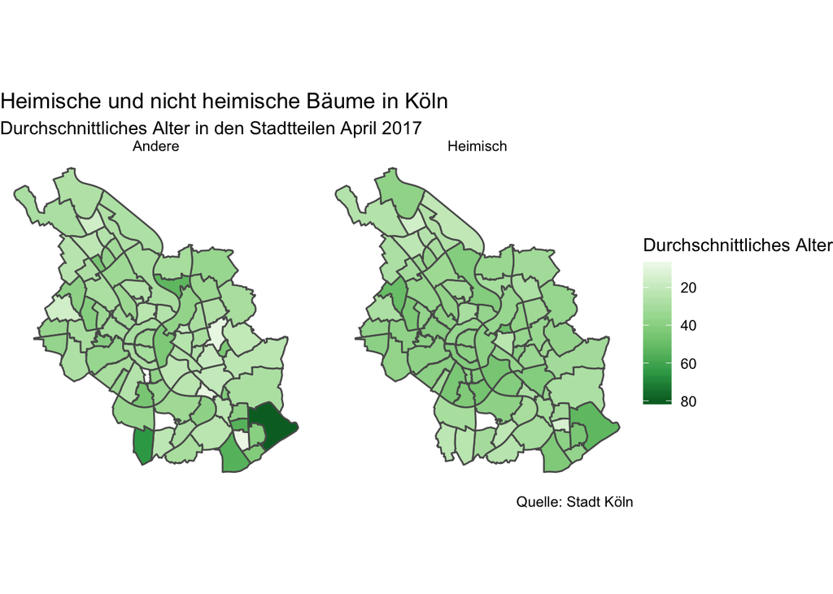

Good overview - but still not revealing. Last try: The same map - but only with the trees that are ten years old or younger:

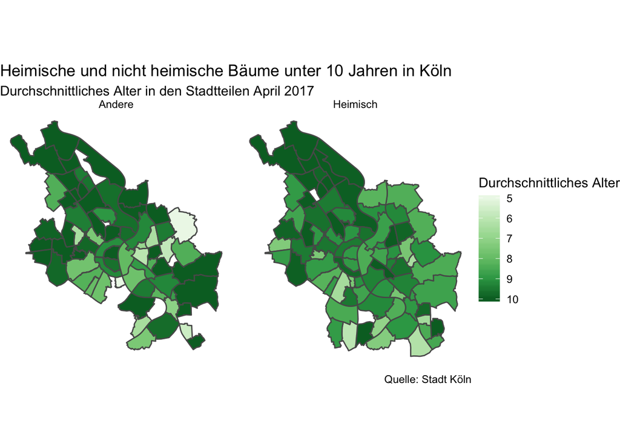

Again: I cannot see that the climate change politics allready took effects for now. Maybe it would be more revealing to simply have a look at the number of domestic and non-domestic trees per quarter. I will try to add this soon.

Other ideas for this dataset that I will try to look at soon are: - Where in Cologne can we find especially big trees? - Where in Cologne can we still find trees that have allready been there during WWII - this could be interessting as the city has been largely destroied during the war.